# Application 1

Author

Martin Hsu

# Simple Random Walk

## Guiding Questions:

Which is more likely: that one team leads for most of the game, or that the lead tends to change frequently over the course of the game?

When would you expect the largest lead (or deficit) to occur — near the beginning, the end, or in the middle of the game? (If the largest lead (or deficit) is attained at several points in the game, when you do expect it to first occur?)

When would you expect the last tie to occur — near the beginning, the end, or in the middle of the game?

## Simulation

Here we simulate a single sample path for difference in scores for 2n steps.

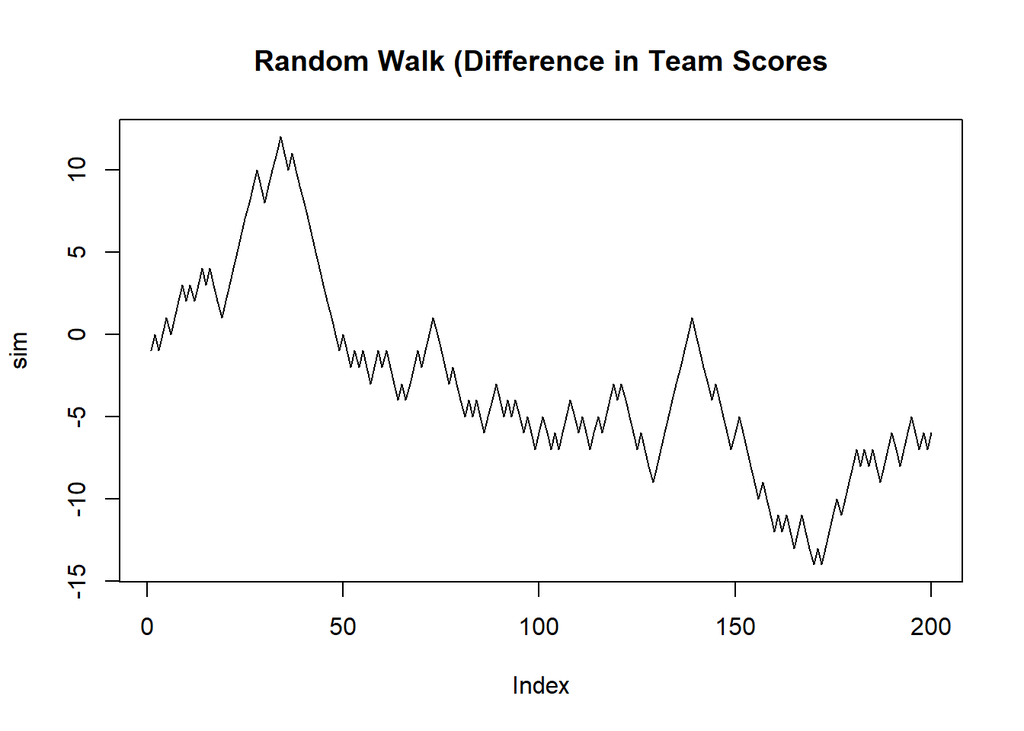

```r
# Set seed for consistent results
set.seed(123)

# Set n
n <- 100
# Simulate who scores each regular unit of time.
# Since the teams are evenly matched, and the score can only increment by 1, we can assume each independent increment follows a Bernoulli distribution.
# If Team A scores, we get a 1, and if Team B scores, we get a 0.
sim <- rbinom(2*n, 1, 0.5)
# Replace indicators with increments.
# If Team A scores, the difference changes by +1.
# If Team B scores, the difference changes by -1.
sim <- replace(sim, sim == 0, -1)
# Find the running difference between Team A and B scores
sim <- cumsum(sim)
plot(sim, type="l", main="Random Walk (Difference in Team Scores")
```

Now, let’s do this multiple times to create a sample of paths.

```r
# Turn our simulation code into a function:
random_walk <- function(n) {
  sim <- rbinom(2*n, 1, 0.5)
  sim <- replace(sim, sim == 0, -1)
  return(cumsum(sim))
}
```

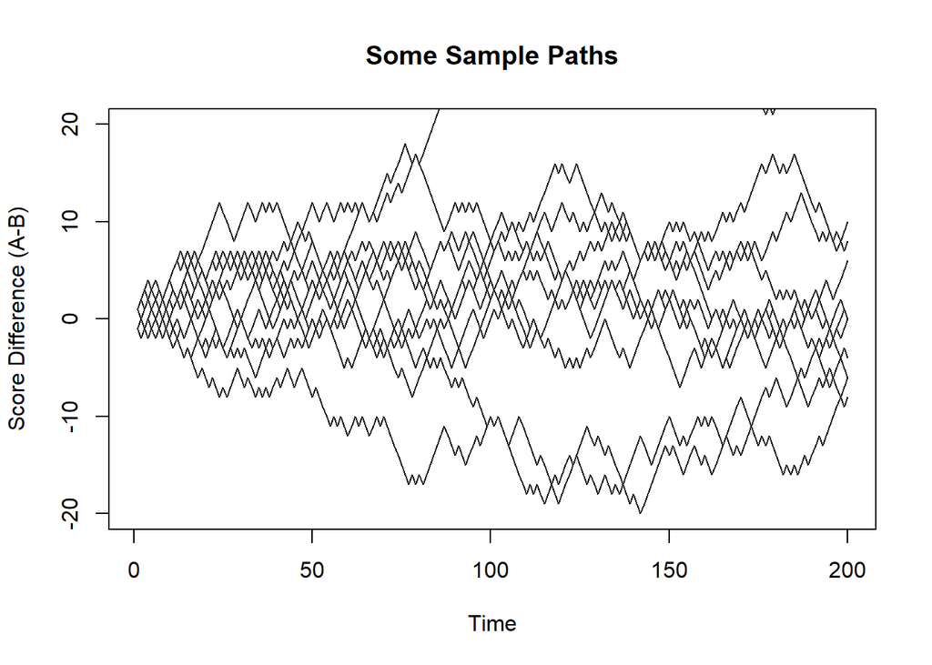

```r
set.seed(1234)

n <- 100
# Specify number of sample paths
reps <- 10000
# Initialize list of paths
samp <- list()
# Create paths
for (i in 1:reps) {
  path <- random_walk(n)
  samp[[i]] <- path

  #Plot some sample paths
  if (i==1) {
    plot(samp[[i]], type="l",main="Some Sample Paths",
         xlab="Time", ylab="Score Difference (A-B)", ylim=c(-20, 20))
  } else if (i %% 1000 == 0) {
    lines(samp[[i]])
  }
}
```

## Calculate T/(2n)

Here is an example:

```r
# Find all indices were the difference in scores is 0
# Then find the highest index
T <- max(which(sim==0))
# Final calculation:
T/(2*n)
```

```
[1] 0.7
```

We can apply this to our sample of paths:

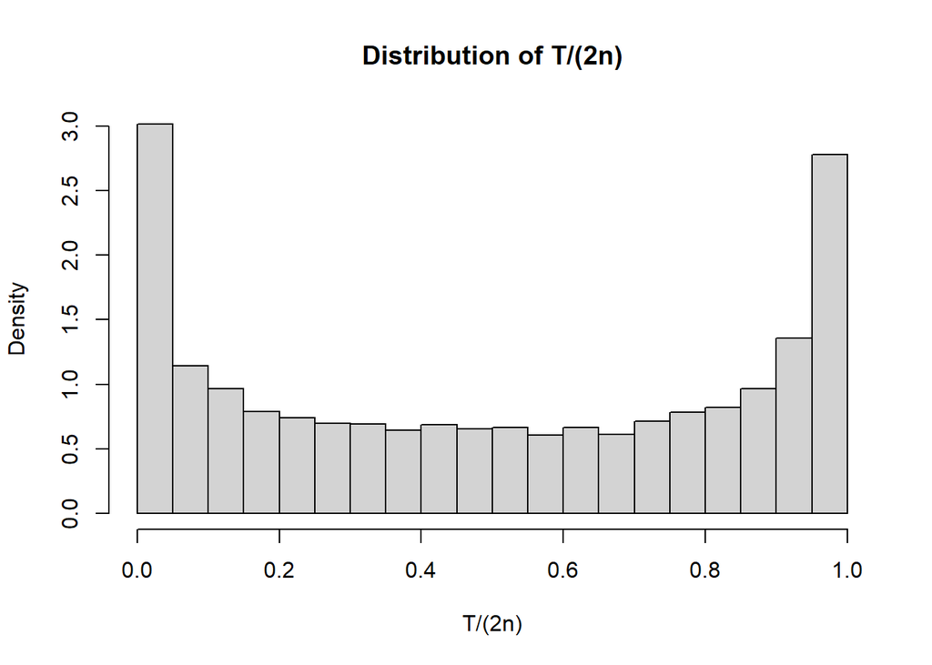

```r
# Initialize vector to store T/(2n)
T_2n <- numeric(reps)
# Find and store T/(2n) for each sample path
for (i in 1:reps) {
  T_2n[i] <- max(which(samp[[i]]==0))/(2*n)
}
T_2n <- replace(T_2n, T_2n==-Inf, 0)
# Plot sampling distribution of T/(2n)
hist(T_2n, main = "Distribution of T/(2n)", freq=F, xlab = "T/(2n)")
```

## Calculate L/(2n)

Here is an example:

```r
# Get a list of indices where the difference >0
# Then find the length of the list
L <- length(which(sim > 0))
# Final calculation:
L/(2*n)
```

```
[1] 0.22
```

We can apply this to our sample of paths:

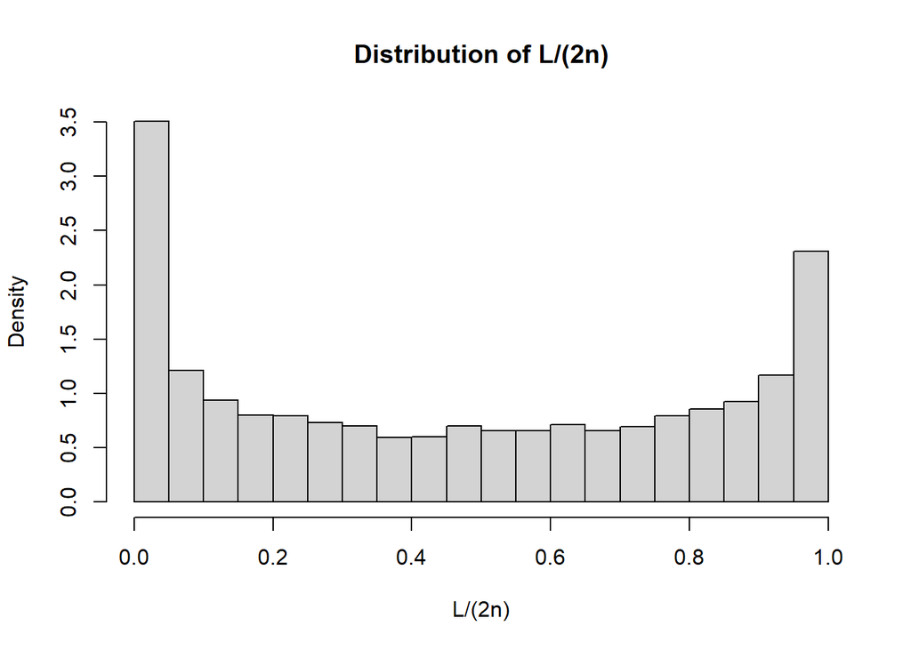

```r
# Initialize vector to store L/(2n)
L_2n <- numeric(reps)
# Find and store L/(2n) for each sample path
for (i in 1:reps) {
  L_2n[i] <- length(which(samp[[i]]>0))/(2*n)
}
# Plot sampling distribution of L/(2n)
hist(L_2n, main = "Distribution of L/(2n)", freq=F, xlab="L/(2n)")
```

## Calculate M/(2n)

Here is an example:

```r
# Find the max difference
max <- max(sim)
# Find the first time the max difference occurs
M <- min(which(sim==max))
M/(2*n)
```

```
[1] 0.17
```

We can apply this to our sample of paths:

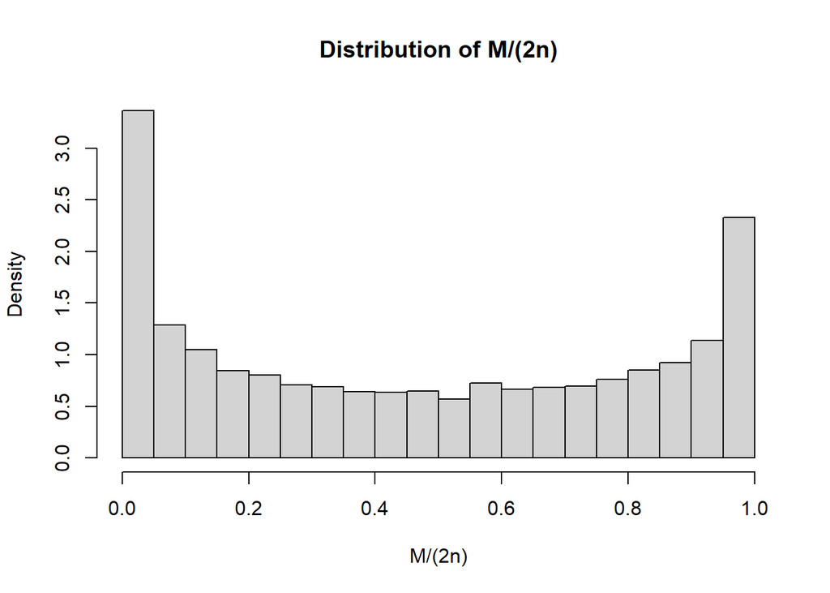

```r
# Initialize vector to store M/(2n)
M_2n <- numeric(reps)
# Find and store M/(2n) for each sample path
for (i in 1:reps) {
  M_2n[i] <- min(which(samp[[i]]==max(samp[[i]])))/(2*n)
}
# Plot sampling distribution of M/(2n)
hist(M_2n, main = "Distribution of M/(2n)", freq=F, xlab="M/(2n)")
```

## Analysis and Interpretation

```r
rvs <- cbind(T_2n, L_2n, M_2n)
psych::describe(rvs)
```

|  | vars | n | mean | sd | median | trimmed | mad | min | max | range | skew | kurtosis | se |
| --- | --- | --- | --- | --- | --- | --- | --- | --- | --- | --- | --- | --- | --- |
| T_2n | 1 | 10000 | 0.5036850 | 0.3550339 | 0.50 | 0.5044688 | 0.533736 | 0.000 | 1 | 1.000 | -0.01053008 | -1.498284 | 0.003550339 |
| L_2n | 2 | 10000 | 0.4722250 | 0.3526384 | 0.46 | 0.4664431 | 0.518910 | 0.000 | 1 | 1.000 | 0.08228133 | -1.484467 | 0.003526384 |
| M_2n | 3 | 10000 | 0.4712165 | 0.3511338 | 0.45 | 0.4646250 | 0.511497 | 0.005 | 1 | 0.995 | 0.10267368 | -1.486126 | 0.003511338 |

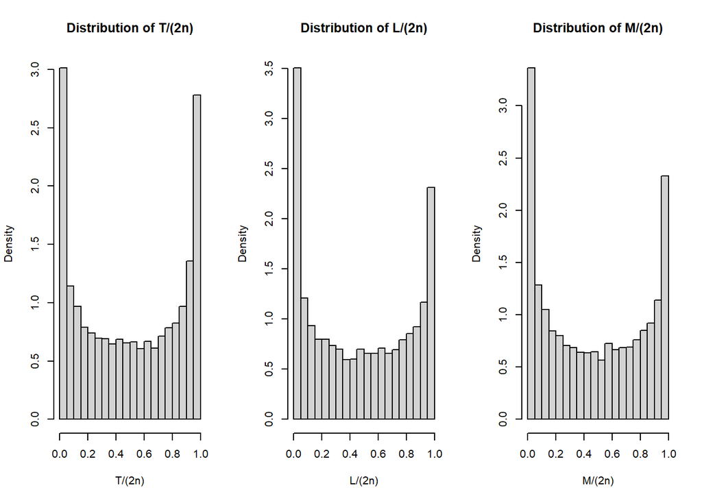

```r
par(mfrow=c(1,3))
hist(T_2n, main = "Distribution of T/(2n)", freq=F, xlab="T/(2n)")
hist(L_2n, main = "Distribution of L/(2n)", freq=F, xlab="L/(2n)")
hist(M_2n, main = "Distribution of M/(2n)", freq=F, xlab="M/(2n)")
```

Based on our simulation:

- The mean of $T/(2n)$ occurs at around 0.5. Therefore, on average, we expect the last tie to happen halfway through the game. However, the most frequent values of $T/(2n)$ tend to occur at 0 or 1; therefore, we can infer that the final tie tends to occur at the beginning or end of the game.
- The mean of $L/(2n)$ occurs at around 0.5. Therefore, on average, we expect A to lead half of the time. However, the most frequent values of $T/(2n)$ tend to occur at 0 or 1; therefore, we can infer that one team or the other tends to lead for most of the 2n steps.
- The mean of $M/(2n)$ occurs at around 0.5. Therefore, on average, we expect the greatest lead (difference between Team A and B scores) to occur for the first time at the midpoint of the match. However, the most frequent values of $M/(2n)$ tend to occur at 0 or 1; therefore, we can infer that greatest lead tends to occur for the first time at the beginning or end of the game.

## Adjusting n

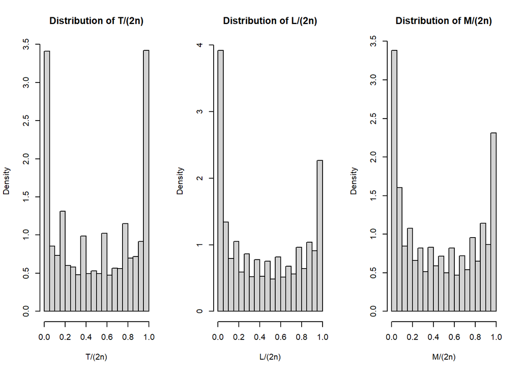

```r
n <- 25

reps <- 10000
samp <- list()
for (i in 1:reps) {
  path <- random_walk(n)
  samp[[i]] <- path
}

T_2n <- numeric(reps)
L_2n <- numeric(reps)
M_2n <- numeric(reps)

for (i in 1:reps) {
  T_2n[i] <- max(which(samp[[i]]==0))/(2*n)

  L_2n[i] <- length(which(samp[[i]]>0))/(2*n)

  M_2n[i] <- min(which(samp[[i]]==max(samp[[i]])))/(2*n)
}
T_2n <- replace(T_2n, T_2n==-Inf, 0)

par(mfrow=c(1,3))
hist(T_2n, main = "Distribution of T/(2n)", freq=F, xlab="T/(2n)")
hist(L_2n, main = "Distribution of L/(2n)", freq=F, xlab="L/(2n)")
hist(M_2n, main = "Distribution of M/(2n)", freq=F, xlab="M/(2n)")
```

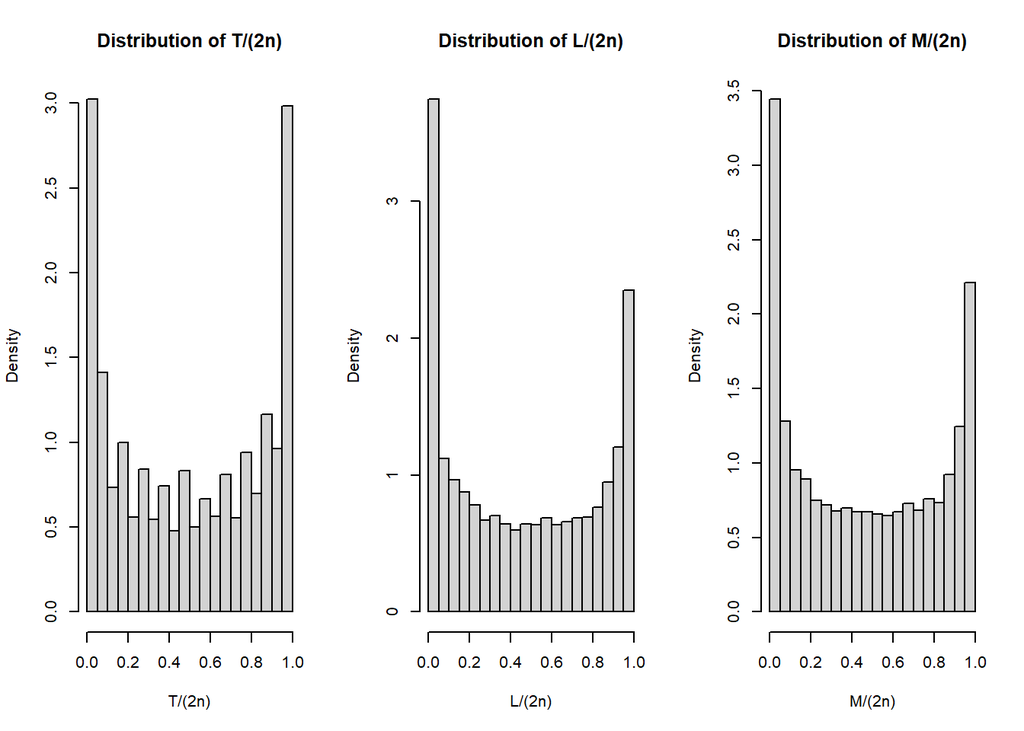

```r
n <- 50

reps <- 10000
samp <- list()
for (i in 1:reps) {
  path <- random_walk(n)
  samp[[i]] <- path
}

T_2n <- numeric(reps)
L_2n <- numeric(reps)
M_2n <- numeric(reps)

for (i in 1:reps) {
  T_2n[i] <- max(which(samp[[i]]==0))/(2*n)

  L_2n[i] <- length(which(samp[[i]]>0))/(2*n)

  M_2n[i] <- min(which(samp[[i]]==max(samp[[i]])))/(2*n)
}
T_2n <- replace(T_2n, T_2n==-Inf, 0)

par(mfrow=c(1,3))
hist(T_2n, main = "Distribution of T/(2n)", freq=F, xlab="T/(2n)")
hist(L_2n, main = "Distribution of L/(2n)", freq=F, xlab="L/(2n)")
hist(M_2n, main = "Distribution of M/(2n)", freq=F, xlab="M/(2n)")
```

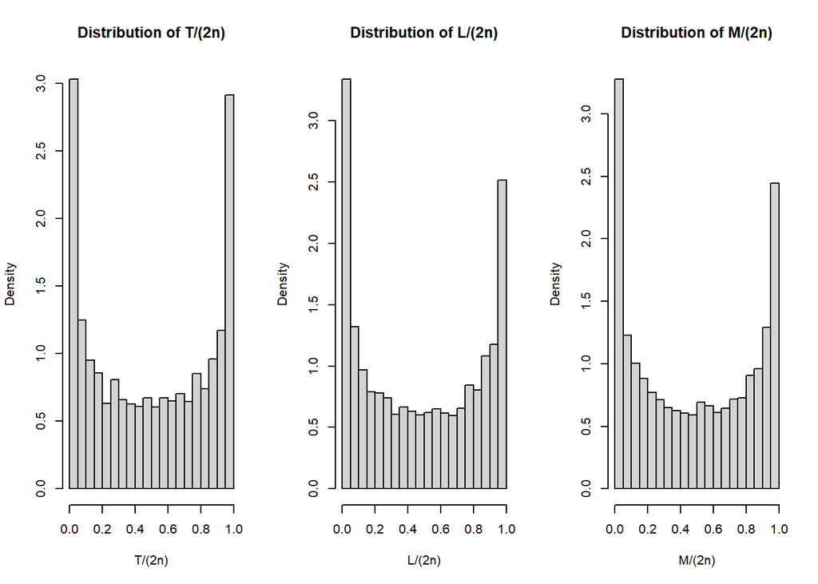

```r
n <- 250

reps <- 10000
samp <- list()
for (i in 1:reps) {
  path <- random_walk(n)
  samp[[i]] <- path
}

T_2n <- numeric(reps)
for (i in 1:reps) {
  T_2n[i] <- max(which(samp[[i]]==0))/(2*n)

  L_2n[i] <- length(which(samp[[i]]>0))/(2*n)

  M_2n[i] <- min(which(samp[[i]]==max(samp[[i]])))/(2*n)
}
T_2n <- replace(T_2n, T_2n==-Inf, 0)

par(mfrow=c(1,3))
hist(T_2n, main = "Distribution of T/(2n)", freq=F, xlab="T/(2n)")
hist(L_2n, main = "Distribution of L/(2n)", freq=F, xlab="L/(2n)")
hist(M_2n, main = "Distribution of M/(2n)", freq=F, xlab="M/(2n)")
```